# Routine for TerraClim data extraction

LSHTM - PHID

Gabriel Carrasco Escobar

UC San Diego / LSHTM (visitor)

*Inquiries regarding this code contact gabriel.carrasco@lshtm.ac.uk*

# LOADING PACKAGES

```r
rm(list=ls())
library(tidyverse); library(maptools); library(epiDisplay)
library(sp); library(sf); library(climateR)
#devtools::install_github("mikejohnson51/climateR")
```

# ADMINISTRATIVE DATA (Shapefile)

```r
library(GADMTools)
LOR <- gadm_sp_loadCountries("PER", level=3, basefile="./") %>%
  gadm_subset(level = 1, regions="Loreto")
LOR<-st_as_sf(LOR$spdf)
```

# LORETO

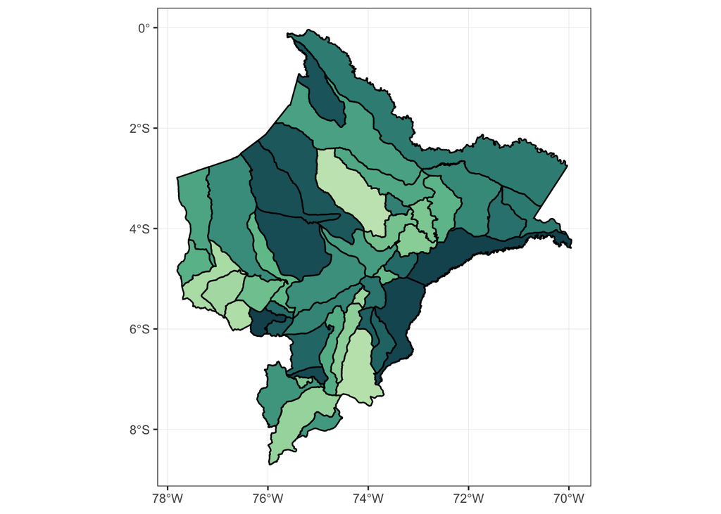

```r
library(colorspace)
LOR %>%
  ggplot() +
  geom_sf(aes(fill=NAME_3), size = 0.5, col = "black") +
  scale_fill_discrete_sequential("BluGrn") +
  guides(fill=F) +
  theme_bw()
```

# TerraClim data

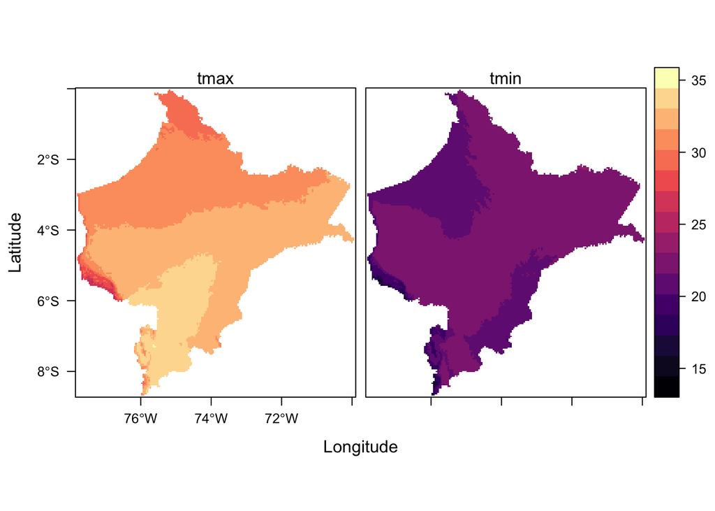

```r
AOI = getAOI(clip = LOR)
p = AOI %>% getTerraClim(param = c('tmax','tmin'), startDate = "2017-10-28")
r = raster::stack(p$tmax, p$tmin)
names(r) = c('tmax', 'tmin')
r <- raster::mask(r, LOR)
rasterVis::levelplot(r)
```

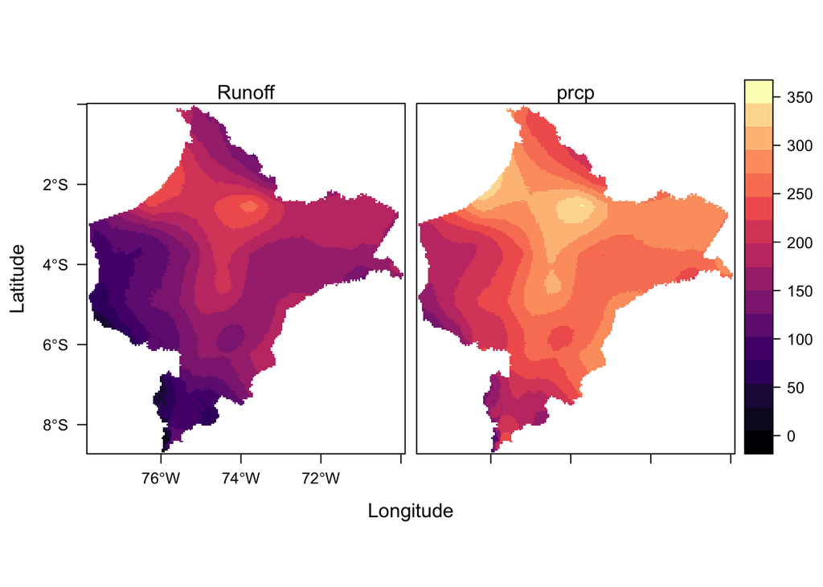

```r
e = AOI %>% getTerraClim(param = c('q','prcp'), startDate = "2017-10-28")
r2 = raster::stack(e$q, e$prcp)
names(r2) = c('Runoff', 'prcp')
r2 <- raster::mask(r2, LOR)
rasterVis::levelplot(r2)
```

# FUNCTIONS to climate data extraction and visualization

```r
devtools::source_gist("3ca747e7d7a7ed2658257b71b4685bc8")
```

1. `clim_dat` function to extract data from TerraClimate in `sf` format

Arguments:

`shp` shapefile or sf object of the AOI boundaries

`par` list of parameters to be extracted from TerraClim. Valid options include: ‘aet’, ‘water_deficit’, ‘palmer’, ‘pet’, ‘prcp’, ‘q’, ‘soilm’, ‘srad’, ‘swe’, ‘tmax’, ‘tmin’, ‘vp’, ‘vpd’, ‘wind’

`fun` function passed on directly to `raster::extract`

`start` start date for pulling TerraClimate data. Default=“2000-01-01”

`end` end date for pulling TerraClimate data. Default=“2017-12-01”

2. `filled.contour.tidy` function to plot 2d contour surfaces `tidyverse` format

Arguments:

`dat` dataset

`month` variable name for month scale

`year` variable name for year scale

`var` attribute name

`hline` yintercept values passed on directly to `geom_hline`

`palette` palette name passed on directly to `scale_fill_distiller`

`trans` name of a scale transformation passed on directly to `scale_fill_distiller`

`log1` wether `var` be transformed to `log10`

`dire` direction of scale passed on directly to `scale_fill_distiller`

# PROCESSING TerraClim data (single parameter / single date)

```r
LOR.tmax <- clim_dat(LOR, par = "tmax", start="2000-01-01", end="2000-01-01")
head(LOR.tmax)
```

```
## Simple feature collection with 6 features and 17 fields
## geometry type:  POLYGON
## dimension:      XY
## bbox:           xmin: -77.80744 ymin: -6.032907 xmax: -75.36609 ymax: -3.670848
## epsg (SRID):    4326
## proj4string:    +proj=longlat +datum=WGS84 +no_defs
##           GID_0 NAME_0    GID_1 NAME_1 NL_NAME_1      GID_2        NAME_2
## PER_17593   PER   Peru PER.17_1 Loreto      <NA> PER.17.1_1 Alto Amazonas
## PER_17100   PER   Peru PER.17_1 Loreto      <NA> PER.17.1_1 Alto Amazonas
## PER_17369   PER   Peru PER.17_1 Loreto      <NA> PER.17.1_1 Alto Amazonas
## PER_17404   PER   Peru PER.17_1 Loreto      <NA> PER.17.1_1 Alto Amazonas
## PER_16810   PER   Peru PER.17_1 Loreto      <NA> PER.17.1_1 Alto Amazonas
## PER_17112   PER   Peru PER.17_1 Loreto      <NA> PER.17.1_1 Alto Amazonas
##           NL_NAME_2        GID_3      NAME_3 VARNAME_3 NL_NAME_3   TYPE_3
## PER_17593      <NA> PER.17.1.1_1 Balsapuerto      <NA>      <NA> Distrito
## PER_17100      <NA> PER.17.1.2_1    Barranca      <NA>      <NA> Distrito
## PER_17369      <NA> PER.17.1.3_1  Cahuapanas      <NA>      <NA> Distrito
## PER_17404      <NA> PER.17.1.4_1     Jeberos      <NA>      <NA> Distrito
## PER_16810      <NA> PER.17.1.5_1     Lagunas      <NA>      <NA> Distrito
## PER_17112      <NA> PER.17.1.6_1  Manseriche      <NA>      <NA> Distrito
##           ENGTYPE_3 CC_3 HASC_3 X2000.01                       geometry
## PER_17593  District <NA>   <NA> 29.52973 POLYGON ((-76.33573 -5.9092...
## PER_17100  District <NA>   <NA> 29.55987 POLYGON ((-77.71257 -5.1586...
## PER_17369  District <NA>   <NA> 29.82984 POLYGON ((-76.85933 -5.7751...
## PER_17404  District <NA>   <NA> 31.38515 POLYGON ((-75.95116 -5.4392...
## PER_16810  District <NA>   <NA> 31.47364 POLYGON ((-75.36609 -5.0575...
## PER_17112  District <NA>   <NA> 30.31590 POLYGON ((-77.71257 -5.1586...
```

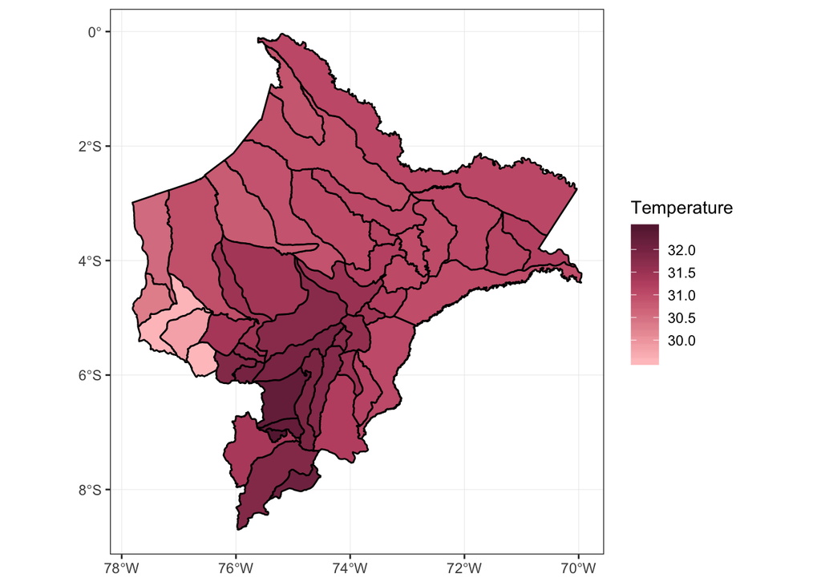

```r
LOR.tmax %>%
  ggplot() +
  geom_sf(aes(fill=`X2000.01`), size = 0.5, col = "black") +
  scale_fill_continuous_sequential("Burg") +
  labs(fill = "Temperature") +
  theme_bw()
```

# PROCESSING TerraClim data (multiple parameters / multiple dates)

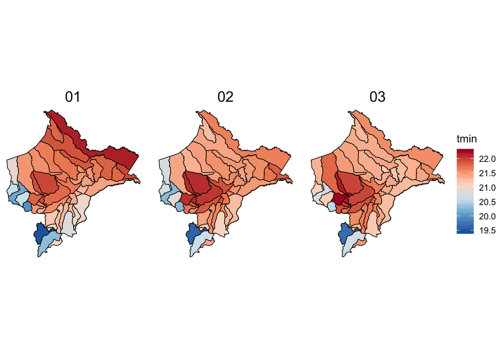

```r
p<-c('tmax', 'tmin')
names(p) <- p #Important

clim_dt <- p %>%
  purrr::map(~clim_dat(shp=LOR, ., end="2000-03-01")) %>%
  bind_rows( .id = "var") %>%
  ungroup()

# Data wrangling
clim_dt_long <- clim_dt %>%
  dplyr::select(NAME_3, var, starts_with("X")) %>% #Change name of the ID-spatial unit (NAME_3)
  gather(date, value, -NAME_3, -var, -geometry) %>%
  spread(var,value) %>%
  mutate(date=str_remove_all(date,"X")) %>%
  separate(date,c("year","month"))

#Ploting
clim_dt_long %>%
  ggplot() +
  geom_sf(aes(fill=tmin), size = 0.3, col = "black") +
  scale_fill_distiller(palette = "RdBu") +
  theme_void()  +
  theme(panel.grid.major = element_line(color = "white"),
        strip.text = element_text(size=15)) +
  facet_wrap(.~month, nrow = 1, ncol = 3)
```

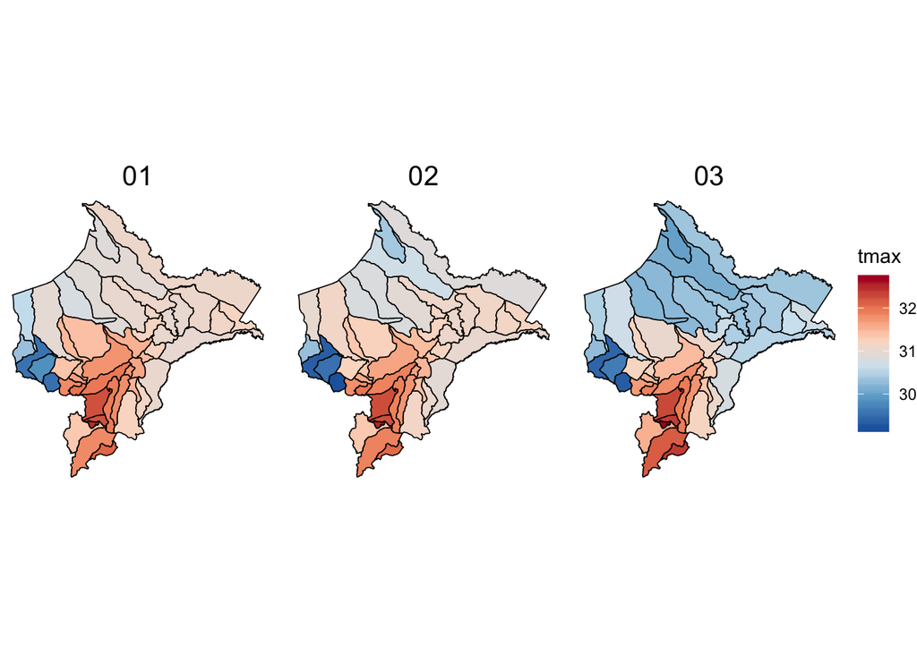

```r
clim_dt_long %>%
  ggplot() +
  geom_sf(aes(fill=tmax), size = 0.3, col = "black") +
  scale_fill_distiller(palette = "RdBu") +
  theme_void()  +
  theme(panel.grid.major = element_line(color = "white"),
        strip.text = element_text(size=15)) +
  facet_wrap(.~month, nrow = 1, ncol = 3)
```

# PROCESSING TerraClim data (single parameters / multiple dates) [Entire Region]

```r
LOR.reg <- gadm_sp_loadCountries("PER", level=1, basefile="./") %>%
  gadm_subset(level = 1, regions="Loreto")
LOR.reg<-st_as_sf(LOR.reg$spdf)

LOR.prcp <- clim_dat(LOR.reg, par = "prcp", start="2000-01-01", end="2017-12-01")

# Data wrangling
LOR.prcp_long <- LOR.prcp %>%
  as.data.frame() %>%
  dplyr::select(NAME_1, starts_with("X")) %>% #Change name of the ID-spatial unit (NAME_3)
  gather(date, prcp, -NAME_1) %>%
  mutate(date=str_remove_all(date,"X")) %>%
  separate(date,c("YEAR","MONTH")) %>%
  mutate_at(c("YEAR","MONTH"), as.numeric)
```

# CONTOUR.PLOT - TIDY

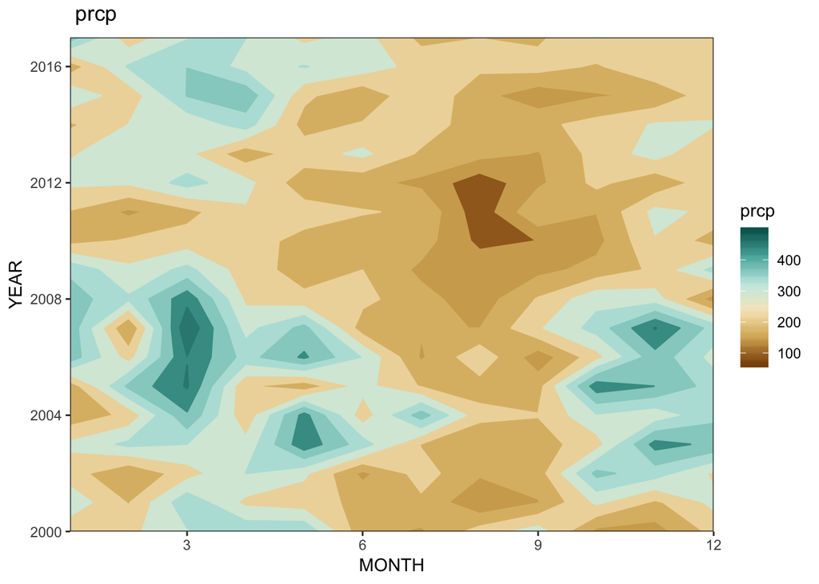

```r
filled.contour.tidy(LOR.prcp_long, MONTH, YEAR, prcp, palette = "BrBG", dire = 1, log1 = F)
```